# A gentle introduction in R

Darren Yeo

2023-10-26

# 1 What is R?

R is a open-sourced popular programming language that is often used for statistical computing and data science. It is compatible in multiple UNIX platforms, Windows or Mac and can be easily downloaded here: https://cran.r-project.org/mirrors.html. R is also commonly programmed in a integrated development environment (IDE) known as Rstudio that is available here: https://posit.co/download/rstudio-desktop/

## 1.1 Why use R?

- Multiple Resources and packages developed for data analyses, data visualization and machine leanrning (ML)
- Wide range of statistical method available like clustering, dimension reduction, statistical hypothesis testing and many more.
- Multiple packages for data visualization
- Most importantly, its FREE!!!!

# 2 R Basics

## 2.1 Rstudio environment

[figure not shown]

Interface of the Rstudio environment.

## 2.2 Print a number or text in R

To print something like a number in the console of R, type a number in the console or script and press “Enter”. **Note:** It is probably more practical to write your code in the script as this way, you can save the contents of the code.

```r
4
```

```
## [1] 4
```

```r
-6
```

```
## [1] -6
```

```r
0
```

```
## [1] 0
```

To print a text in the console, use the function “print” followed by the text within a bracket. You can also print a “text” without the “print” function in R. This is however not neccessarily universal for all languages. In Python for instance, you need to use the “print” function to print a text

```r
print("Hello World!")
```

```
## [1] "Hello World!"
```

```r
"Hello World!"
```

```
## [1] "Hello World!"
```

Additionally, if you write a loop and want to print something within the loop, the “print” function is neccessary for printing of the text or number as shown.

```r
for (i in 1:10){
  print(i)
}
```

```
## [1] 1
## [1] 2
## [1] 3
## [1] 4
## [1] 5
## [1] 6
## [1] 7
## [1] 8
## [1] 9
## [1] 10
```

## 2.3 Comments in R

Comments are useful to explain what a line of code does. It will come in handy when one writes functions or loops that does multiple operations

```r
print ("Hello World!") #This code will print Hello World!
```

```
## [1] "Hello World!"
```

It is additionally useful when you do no want to run a particular line of code.

```r
#Print only text but not numbers
print ("Hello World!") #This code will print Hello World!
```

```
## [1] "Hello World!"
```

```r
#print (1)
```

## 2.4 Mathematical operations

R is a calculator. You can treat R like a calculator and perform simple mathematical operations.

```r
5 + 5 # Addition
```

```
## [1] 10
```

```r
5 - 2 # Subtraction
```

```
## [1] 3
```

```r
5 * 3 # Multiplication
```

```
## [1] 15
```

```r
6 ^ 2 # Exponential
```

```
## [1] 36
```

```r
9 / 2 # Division
```

```
## [1] 4.5
```

```r
9 %/% 2 # Integer Division
```

```
## [1] 4
```

```r
9 %% 2 # Modulo (Calculate the remainder of the Division)
```

```
## [1] 1
```

R also has multiple built in mathematical functions that you can use.

```r
log(5) # natural Logarithm of 5
```

```
## [1] 1.609438
```

```r
log10(5) # Logarithm with base 10 of 5
```

```
## [1] 0.69897
```

```r
cos(2) # Cosine of 2
```

```
## [1] -0.4161468
```

```r
sqrt(16) # Squareroot von 16
```

```
## [1] 4
```

```r
exp(2) # Exponential of e
```

```
## [1] 7.389056
```

## 2.5 Variables in R

Variables in R are often defined with either “<-” or “=”. The names of the variable is often found before the operator while the content of the variable is found after the operator.

```r
a <- 2
print(a)
```

```
## [1] 2
```

```r
b = 2
print(b)
```

```
## [1] 2
```

Math operators can be performed on variables.

```r
a <- 2
b = 2
a + b
```

```
## [1] 4
```

```r
a * b
```

```
## [1] 4
```

Text (more commonly known as characters or strings in programming) can also be saved as variables

```r
string <- "This is a string"
print(string)
```

```
## [1] "This is a string"
```

## 2.6 Boolean or Logistic values

In programming languages, we often need to know if an expression is either **TRUE** or **FALSE**. When you for instance, compare two numeric values with an mathematical expression, the answer will either be **TRUE** or **FALSE**. Internally in R-engine, the logistical values are saved as binary values (**1** or **0**). It is however more intuitive for us as humans to recognise **TRUE** or **FALSE**

### 2.6.1 Examples of such Expressions:

- “<” (Smaller)
- “>” (Larger)
- “<=” (Smaller or equals to)
- “>=” (Larger or equals to)
- “==” (equals to)
- “!=” (Is not equals to)
- “&” (And)
- “|” (Or)

```r
8 < 10 #TRUE, 8 is smaller than 10
```

```
## [1] TRUE
```

```r
8 > 10 #FALSE, 8 is not smaller than 10
```

```
## [1] FALSE
```

```r
9 == 9 #TRUE, 9 is equals to 9
```

```
## [1] TRUE
```

```r
5 != 12 #TRUE, 5 is not equals to 12
```

```
## [1] TRUE
```

With the **&** and **|** expression, one could include conditions. **|** means that only one of the two conditions needs to be TRUE while **&** means both of the conditions needs to be TRUE

```r
5 == 5 | 5 < 8 #Eine von der Bedingungen ist erfüllt -> TRUE
```

```
## [1] TRUE
```

```r
5 == 5 & 5 < 2 #Nur eine von der Bedingungen ist erfüllt -> FALSE
```

```
## [1] FALSE
```

## 2.7 R exercises: Reinforce your knowlege

1. Print out the text “Hello my name is (insert_your_name)”
2. Perform a series of mathematical operations on numerical values:
   - What is the square root of 1400
   - What is the value of the $(\frac{2^6}{8})$
   - What is the remainder of $(\frac{254}{8})$
   - What is the value of $e^5$
3. Can mathematical operations be performed on strings? Try it yourself!
   - Did it work? If not think about how this can be performed on strings
4. Save a numeric value and string as separate variables. You can choose the names yourself.
   - Find out the value of the numeric variable divided by 5
   - what is the value of the numeric variable multiplied by 5
   - Add the number 5 to the string variable (Think about how you can do that, similar principle to question 3)
5. Is this expression **TRUE** or **FALSE** and why?
   - 8 > 5
   - 8 >= 8
   - “string” == 7
   - “Apples” != “Apples”
   - “Apples” != “Apples” | “Orange” == “Orange”
   - “Apples” != “Apples” & “Orange” == “Orange”

# 3 Types of data in R

Values in R can be in principle divided into three classes or types;

- Numbers
- Characters
- Logical values or Boolean values

With the “class” or “typeof” function, the type of data can be revealed.

```r
Zahl <- 6
class(Zahl) # numeric as 6 is a number
```

```
## [1] "numeric"
```

```r
Wort <- "World"
class(Wort) # character as "World" is a string
```

```
## [1] "character"
```

```r
Boolean <- TRUE
class(Boolean) # Boolean as its either TRUE or FALSE
```

```
## [1] "logical"
```

## 3.1 Numeric values

Numeric values can be further divied into three types:

- Numeric (Also known as double or more commonly as float). They are real numbers such as 6, 6.7, 3.67, 1/7, 6^-3

```r
class(6)
```

```
## [1] "numeric"
```

```r
class(6.7)
```

```
## [1] "numeric"
```

```r
class(1/7)
```

```
## [1] "numeric"
```

```r
class(6^-3)
```

```
## [1] "numeric"
```

- Integer (Whole numbers like 1,3,-5, 77)

**NOTE**: All integers can be saved as floats but not all floats can be saved as integers. If you save a whole number as a variable and thereafter verify the class of the variable with “class()” or “typeof()”, the output in the console will always be “numeric” or “double” as the number will be saved as numeric values. To save a whole number specifically as integer, you need to save it with the function “as.integer()”

```r
class(as.integer(6))
```

```
## [1] "integer"
```

```r
Zahl <- as.integer(6)
class(Zahl)
```

```
## [1] "integer"
```

- Complex values. This is however not so relevant for most R users.

```r
z = 1 + 2i
class(z)
```

```
## [1] "complex"
```

## 3.2 Character values

Characters (also often known as strings) are always written in R with quotation marks.

```r
class("Hello")
```

```
## [1] "character"
```

```r
Wort <- "Hello"
class(Wort)
```

```
## [1] "character"
```

Without the quotation marks, “Hello” will not be recognized as a character.

```r
class(Hello)
```

```
## Error in eval(expr, envir, enclos): object 'Hello' not found
```

Even numeric values can be saved as a character.

```r
Zahl <- "6"
class(Zahl)
```

```
## [1] "character"
```

## 3.3 Boolean values

Either **TRUE** or **FALSE** (Saved either as **1** or **0** in R ), nothing more nothing less.

## 3.4 R exercises: Reinforce your knowlege

1. What is the difference between 6 and 6.6
2. What is the difference between 6 and “6”
- Can they be added together? why or why not?
3. Save the number 6 as an integer
- Can the integer 6 be added to the numeric 6.6? why or why not?

# 4 The different data structures in R

Ther are multiple datastructures in R like vectors, matrices, dataframes, lists, arrays and factors. In this tutorial, we will focus primarily on vectors, matrices and dataframes

## 4.1 Vectors

Vector is a basic datastructure in programming that can be thought of as a collection of elements. With the concatenate “c()” function, one can build a vector of different elements (character or numeric)

### 4.1.1 Creating a vector

Here is an example of a character vector of animals.

```r
Animals <- c("Lion","Tiger","Monkey","Cat") # Character vector of animals
print(Animals) # Print the vector
```

```
## [1] "Lion"   "Tiger"  "Monkey" "Cat"
```

Elements of vectors can also be be numeric. In this case, the vector will be save as an numeric vector.

```r
Numbers <- c(2,3,5,6,7,11,13) # A prime number vector
print(Numbers) # Print the vector
```

```
## [1]  2  3  5  6  7 11 13
```

Wenn die Zahlen mit Anführungszeichen gespeichert werden, wird die Vektor als Charakter Vektor gespeichert

**NOTE:** If you save the numbers as characters like the following example, it will be saved as a character vector.

```r
Numbers <- c("2","3","5","6","7","11","13") # Prime numbers saved as a character vector
class(Numbers)
```

```
## [1] "character"
```

You can however change it to a numeric or integer vector like the following example.

```r
Numbers <- c("2","3","5","6","7","11","13") # Charakter Vektor von Primzahlen wird erstellt
Numbers <-  as.numeric(Numbers) # Umwandeln von Charakter Vektor auf numerische Vektor
class(Numbers)
```

```
## [1] "numeric"
```

You cannot have save multiple data of different classes in the vector. In this case, we see three data types characters, numbers and boolean. The numeric values and boolean values will be automatically saved as characters.

```r
Animals_Numbers_boolean <- c("Lion","Tiger","Monkey","Cat",1,2,3,4,5,TRUE,FALSE) # Will be saved as character vector
class(Animals_Numbers_boolean)
```

```
## [1] "character"
```

This is however not always the case. Given a vector with numeric and boolean values, the boolean values will be converted to binary values (1 and 0).

```r
Numbers_boolean <- c(1,2,3,4,5,TRUE,FALSE) # will be saved as numeric vector
class(Numbers_boolean)
```

```
## [1] "numeric"
```

### 4.1.2 Math operations with vectors

As with single numeric values, math operations can be performed on numeric vectors

```r
Numbers <- c(2,4,5,7,9) # Numeric vector
Numbers + 2 # Addition of numeric Vector
```

```
## [1]  4  6  7  9 11
```

```r
Numbers - 2 # Subtraction of numeric Vector
```

```
## [1] 0 2 3 5 7
```

```r
Numbers * 2 # Multiplication of numeric Vector
```

```
## [1]  4  8 10 14 18
```

```r
Numbers / 2 # Division of numeric Vector
```

```
## [1] 1.0 2.0 2.5 3.5 4.5
```

```r
log(Numbers) # natural logarithm of numeric vector
```

```
## [1] 0.6931472 1.3862944 1.6094379 1.9459101 2.1972246
```

You can perform mathematical operations on two numeric vectors of the same length.

```r
Numbers <- c(2,4,5,7,9) # First numeric vector
Numbers2 <- c(4,7,2,3,5) # Second numeric vectot
Numbers + Numbers2 # Addition
```

```
## [1]  6 11  7 10 14
```

```r
Numbers - Numbers2 # Subtraction
```

```
## [1] -2 -3  3  4  4
```

If they are of different lengths, the operation will still work. However, the number 7 and 8 from the vector “Numbers2” will be added or subtracted by the number 2 and 4 respectively from the vector “Numbers”.

```r
# Addition or Subtraction of vectors with different length of numeric values will still work.
# best avoid it..
Numbers <- c(2,4,5,7,9)
Numbers2 <- c(4,7,2,3,5,7,8)
Numbers + Numbers2
```

```
## [1]  6 11  7 10 14  9 12
```

```r
Numbers - Numbers2
```

```
## [1] -2 -3  3  4  4 -5 -4
```

Math operations cannot be performed on vectors obviously, however on can add characters into the individual character elements of the vector as you will see in the next section

```r
Fruits <- c("Apples","Lemon","Lime") # Fruits vector
Animals <- c("Lion","Tiger","Monkey") # Animal vector
Fruits + Animals # Addition of
```

```
## Error in Fruits + Animals: non-numeric argument to binary operator
```

### 4.1.3 Adding characters into chracter elements of a character vector

Math operation will not work with character vectors, however you can add a character pattern to each character elements in the character vector.

```r
Fruits <- c("Apples","Lemon","Lime") # Fruits Vector
print(Fruits)
```

```
## [1] "Apples" "Lemon"  "Lime"
```

```r
Fruits <- paste(Fruits,"tasty",sep="_") # Adding the character "tasty" to the the Fruits vector
print(Fruits)
```

```
## [1] "Apples_tasty" "Lemon_tasty"  "Lime_tasty"
```

Two different character vectors can be combined together like so.

```r
Fruits <- c("Apples","Lemon","Lime") # Fruits vector
color <- c("red", "yellow", "green")
print(Fruits)
```

```
## [1] "Apples" "Lemon"  "Lime"
```

```r
print(color)
```

```
## [1] "red"    "yellow" "green"
```

```r
Fruits_color <- paste(Fruits,color,sep="_") # adding the color Vector elements to the fruits Vector elements
print(Fruits_color)
```

```
## [1] "Apples_red"   "Lemon_yellow" "Lime_green"
```

### 4.1.4 Appending elements into a vector

Elements can be added into a vector if needed. A new character can be added to a character vector for instance.

```r
Fruits <- c("Apples","Lemon","Lime") # Fruits vector
Fruits2 <- c(Fruits,"Orange") # append the character "Orange" to the Fruits vector
print(Fruits2)
```

```
## [1] "Apples" "Lemon"  "Lime"   "Orange"
```

This will work with numeric values or boolean values as well.

```r
Numbers <- c(2,4,5,7,9) # numeric vector
Numbers2 <- c(Numbers, 6,9) # concatenate extra numeric values
print(Numbers2)
```

```
## [1] 2 4 5 7 9 6 9
```

### 4.1.5 Indexing and filtering of vectors

Vectors can be filtered according to conditional expressions or by index.

Here is an example of index positional filtering of the fruits vector. **NOTE:** In most programming languages, index positions always starts with 0. This means that the first element of a vector for example will start with 0. In R however, the index positioning begins with 1.

```r
Fruits <- c("Apples","Lemon","Lime","Kiwi","Strawberry") # Fruits vector
Fruits[3] # Print out the third element
```

```
## [1] "Lime"
```

```r
Fruits[1:3] # Print out the first to the third element
```

```
## [1] "Apples" "Lemon"  "Lime"
```

```r
Fruits[c(2,4)] # Print out the second and the fourth element
```

```
## [1] "Lemon" "Kiwi"
```

```r
Fruits[length(Fruits)] # Print the last element, but combined with the "length()" function
```

```
## [1] "Strawberry"
```

Elements of vectors can also be filtered by values. Naturally, the data type of the values has to be the same as the elements in the vector.

```r
Fruits <- c("Apples","Lemon","Lime","Kiwi","Strawberry") # Fruits Vector
Lemon <-  Fruits[Fruits %in% "Lemon"]
print(Lemon)
```

```
## [1] "Lemon"
```

```r
Numbers <-  c(1,5,7,8,4,3) #Numeric Vector
Number_7 <- Numbers[Numbers %in% 7]
print(Number_7)
```

```
## [1] 7
```

Elements of vectors can be filtered by elements of another vector. The data type of the elements in one vector has to be the same as the elements in the other vector.

```r
Fruits <- c("Apples","Lemon","Lime","Kiwi","Strawberry") # Fruits Vector
Fruits2 <- c("Lemon","Strawberry") # Second fruits Vector
Fruits <- Fruits[Fruits %in% Fruits2] # Filter the first fruits vector using the second fruits vector
print(Fruits)
```

```
## [1] "Lemon"      "Strawberry"
```

```r
Numbers <-  c(1,5,7,8,4,3) # Numeric Vector
Numbers2 <- c(5,8,4) # Second numeric Vector
Numbers <- Numbers[Numbers %in% Numbers2] # Filtering the first numeric vector using the second numeric vector
print(Numbers)
```

```
## [1] 5 8 4
```

Numeric vectors can be filtered by conditional expressions.

```r
Numbers <-  c(1,5,7,8,4,3,10,-5,-3,-7,-10) # Numeric vector
Numbers[Numbers > 4] # Filter all values larger than 4
```

```
## [1]  5  7  8 10
```

```r
Numbers[Numbers >= 4] # Filter all values larger or equals to 4
```

```
## [1]  5  7  8  4 10
```

```r
Numbers[Numbers <= 4] # Filter all values smaller or equals to 4
```

```
## [1]   1   4   3  -5  -3  -7 -10
```

```r
Numbers[Numbers < 4] # Filter all values smaller than 4
```

```
## [1]   1   3  -5  -3  -7 -10
```

```r
Numbers[Numbers != 4] # Filter all values that are the equal to 4
```

```
##  [1]   1   5   7   8   3  10  -5  -3  -7 -10
```

### 4.1.6 R exercises: Reinforce your knowlege

1. Create a character vector, numeric vector and boolean vector.
   - Convert the numeric vector to an integer vector.
   - Convert the boolean vector to a character vector.
2. Create two numeric vectors of the same length.
   - Multiply them together
   - Divide the first vector with the second
3. Create a character vector of movie genres of length 5.
   - Add 1 or 2 additionally movie genres into the character vector.
   - Insert the string “on demand” to each of the element in the vector. **NOTE:** Take note of the spacing.
   - Additionally, for each movie genre element in the vector, insert a rating (bad, Watchable, Good)
4. Create a vector of 5 animal names and a vector of 5 numerical values.
   - filter the vector from the 2nd element to the last element for both vectors.
   - filter the 1st **and** 4th element of both vectors
   - For the animal vector, choose one particular animal and filter it.
   - For the numeric vector:
     - filter all values that are smaller than 4
     - filter all values that are larger or equals to 4

## 4.2 Matrices

Matrices are two dimensional data structures that encompasses rows and columns. It can be thought of as a two dimensional data structure that is built from vectors of the same data type Vectors of the same data types can be bound together either by rows “rbind()” or columns “cbind”.

```r
Numbers <-  c(1,5,7,8,4,3,10,-5,-3,-7)
Numbers2 <- c(2,4,20,4,6,7,-2,-6,7,8)
Number.mat <- cbind(Numbers,Numbers2) # Binding vectors by columns
print(Number.mat)
```

```
##       Numbers Numbers2
##  [1,]       1        2
##  [2,]       5        4
##  [3,]       7       20
##  [4,]       8        4
##  [5,]       4        6
##  [6,]       3        7
##  [7,]      10       -2
##  [8,]      -5       -6
##  [9,]      -3        7
## [10,]      -7        8
```

```r
Number.mat <- rbind(Numbers,Numbers2) # Binding vectors by rows
print(Number.mat)
```

```
##          [,1] [,2] [,3] [,4] [,5] [,6] [,7] [,8] [,9] [,10]
## Numbers     1    5    7    8    4    3   10   -5   -3    -7
## Numbers2    2    4   20    4    6    7   -2   -6    7     8
```

One could also create a matrix with a given vector with the “matrix()” function. The structure of the matrix namely the number of rows and columns needs to be defined which is dependent on the length of your given vector.

```r
Number.mat <- matrix(Numbers, nrow = 5,ncol = 2)
print(Number.mat)
```

```
##      [,1] [,2]
## [1,]    1    3
## [2,]    5   10
## [3,]    7   -5
## [4,]    8   -3
## [5,]    4   -7
```

Matrices can also be character based.

```r
Fruits <- c("Apple","Orange","Grape","Strawberry","Lime","Lemon")
Character.mat <- matrix(Fruits,nrow = 3,ncol = 2)
print(Character.mat)
```

```
##      [,1]     [,2]
## [1,] "Apple"  "Strawberry"
## [2,] "Orange" "Lime"
## [3,] "Grape"  "Lemon"
```

### 4.2.1 Mathematical operations and functions on numerical matrices

And similarly to numerical vectors, you can perform math operations on numerical matrices

```r
Number.mat <- matrix(Numbers, nrow = 5,ncol = 2)
print(Number.mat)
```

```
##      [,1] [,2]
## [1,]    1    3
## [2,]    5   10
## [3,]    7   -5
## [4,]    8   -3
## [5,]    4   -7
```

```r
Number.mat * 2
```

```
##      [,1] [,2]
## [1,]    2    6
## [2,]   10   20
## [3,]   14  -10
## [4,]   16   -6
## [5,]    8  -14
```

```r
Number.mat / 2
```

```
##      [,1] [,2]
## [1,]  0.5  1.5
## [2,]  2.5  5.0
## [3,]  3.5 -2.5
## [4,]  4.0 -1.5
## [5,]  2.0 -3.5
```

```r
log10(Number.mat)
```

```
##          [,1]      [,2]
## [1,] 0.000000 0.4771213
## [2,] 0.698970 1.0000000
## [3,] 0.845098       NaN
## [4,] 0.903090       NaN
## [5,] 0.602060       NaN
```

With matrices, we can calculate the some basic statistical value of the rows or columns

```r
Numbers <- c(1,5,7,8,4,3,10,5,3,7,11,14,4,6,8)
Number.mat <- matrix(Numbers, nrow = 5,ncol = 3) # create matrix
print(Number.mat)
```

```
##      [,1] [,2] [,3]
## [1,]    1    3   11
## [2,]    5   10   14
## [3,]    7    5    4
## [4,]    8    3    6
## [5,]    4    7    8
```

```r
colSums(Number.mat) # calculate the sum of values from each column
```

```
## [1] 25 28 43
```

```r
rowSums(Number.mat) # calculate the sum of values from each rows
```

```
## [1] 15 29 16 17 19
```

```r
colMeans(Number.mat) # calculate the mean of values from each columns
```

```
## [1] 5.0 5.6 8.6
```

```r
rowMeans(Number.mat) # calculate the mean of values from each rows
```

```
## [1] 5.000000 9.666667 5.333333 5.666667 6.333333
```

```r
sum(Number.mat) # calculate the sum of the matrix
```

```
## [1] 96
```

### 4.2.2 Indexing and filtering of matrices

Filtering of matrices by index is no different from filtering of vectors by index. The differences is that matrices are 2 dimensional. Depending on how you filter, you will either get a vector, single values or a matrix

```r
Numbers <-  c(1,5,7,8,4,3,10,-5,-3,-7,12,9,14,2,-8)
Number.mat <- matrix(Numbers, nrow = 5,ncol = 3) # create a 5 by 3 matrix
print(Number.mat)
```

```
##      [,1] [,2] [,3]
## [1,]    1    3   12
## [2,]    5   10    9
## [3,]    7   -5   14
## [4,]    8   -3    2
## [5,]    4   -7   -8
```

```r
Number.mat[2,] # Second row
```

```
## [1]  5 10  9
```

```r
Number.mat[,2] # Second column
```

```
## [1]  3 10 -5 -3 -7
```

```r
Number.mat[3,2] # The value in the third row and second column (-5)
```

```
## [1] -5
```

```r
Number.mat[1:3,2:3] # First row to third row, Second column to third column, a matrix
```

```
##      [,1] [,2]
## [1,]    3   12
## [2,]   10    9
## [3,]   -5   14
```

```r
Number.mat[1:5,c(1,3)] # First row to fifth row, first and third column, a matrix
```

```
##      [,1] [,2]
## [1,]    1   12
## [2,]    5    9
## [3,]    7   14
## [4,]    8    2
## [5,]    4   -8
```

Filtering of numerical matrix by mathematical expressions is slightly different from vectors.

```r
Numbers <-  c(1,5,7,8,4,3,10,-5,-3,-7,12,9,14,2,-8)
Number.mat <- matrix(Numbers, nrow = 5,ncol = 3) # create a 5 by 3 matrix
print(Number.mat)
```

```
##      [,1] [,2] [,3]
## [1,]    1    3   12
## [2,]    5   10    9
## [3,]    7   -5   14
## [4,]    8   -3    2
## [5,]    4   -7   -8
```

```r
Number.mat >=5 # This is a logical expression and will return a boolean matrix of TRUE and FALSE if the values in the matrix are larger than or equals to 5
```

```
##       [,1]  [,2]  [,3]
## [1,] FALSE FALSE  TRUE
## [2,]  TRUE  TRUE  TRUE
## [3,]  TRUE FALSE  TRUE
## [4,]  TRUE FALSE FALSE
## [5,] FALSE FALSE FALSE
```

```r
Number.mat[Number.mat >= 5] # This will filter out all values that are larger than or equals to five
```

```
## [1]  5  7  8 10 12  9 14
```

### 4.2.3 R exercises: Reinforce your knowlege

1. Create a 5 by 3 matrix of numerical values.
2. Find out for each value of the matrix, the natural logarithm value.
3. Create a another 5 by 2 matrix of numerical values.
   - combine this matrix together with the first matrix to achieve a 5 by 5 matrix.
4. For the first numerical matrix, calculate;
   - The column means
   - The row means
   - The sum of the matrix
5. Now create a character a 4 by 3 character matrix of different fruits.
   - Index the 3rd row of the matrix
   - Index the 4th row and 2nd column of the matrix
   - Index the 2nd to the 4th row and index the 1st and 3rd columns of the matrix
   - Choose a particular fruit in the matrix, and filter that particular fruit

## 4.3 Data frames in R

Data frame is a special from of matrix that can consists of differing data types. This includes numerical vectors, boolean vectors or character vectors. This makes it particularly useful for us in data analyses. One can create a data frame with the function “data.frame().”

```r
Numbers <-  c(1,5,7,8,4) # numerical vector
Fruits <- c("Apple","Orange","Grape","Strawberry","Lime") # Fruits vector
Binary <- c(TRUE,FALSE,TRUE,TRUE,FALSE) # Boolean vector
Df <- data.frame(Numbers,Fruits,Binary)
print(Df)
```

```
##   Numbers     Fruits Binary
## 1       1      Apple   TRUE
## 2       5     Orange  FALSE
## 3       7      Grape   TRUE
## 4       8 Strawberry   TRUE
## 5       4       Lime  FALSE
```

Like matrices, you can filter each column of the data frames.

```r
Df <- data.frame(Numbers,Fruits,Binary)
print(Df)
```

```
##   Numbers     Fruits Binary
## 1       1      Apple   TRUE
## 2       5     Orange  FALSE
## 3       7      Grape   TRUE
## 4       8 Strawberry   TRUE
## 5       4       Lime  FALSE
```

```r
Df$Fruits
```

```
## [1] "Apple"      "Orange"     "Grape"      "Strawberry" "Lime"
```

```r
Df$Binary
```

```
## [1]  TRUE FALSE  TRUE  TRUE FALSE
```

```r
Df[1,2]
```

```
## [1] "Apple"
```

Naturally, the data type of the filtered column is dependent the type of data that makes up the column itself

```r
class(Df$Fruits)
```

```
## [1] "character"
```

```r
class(Df$Binary)
```

```
## [1] "logical"
```

```r
class(Df[1,2])
```

```
## [1] "character"
```

With data frames, it is often extremely practical to use the “tidyverse” environment. We will continue our work with data frames in in the tidyverse chapter.

# 5 Functions in R

Functions in programming is a self-contained chunk of code that runs specific tasks that were written within the function itself. It allows you to automate your task which is in general a more practical solution to copy-and-pasting chunks of code. One should consider writting functions when a specific tasks has been repeated constantly.

Functions expects input or inputs and will return an output or outputs which highly depend on how one defined their functions.

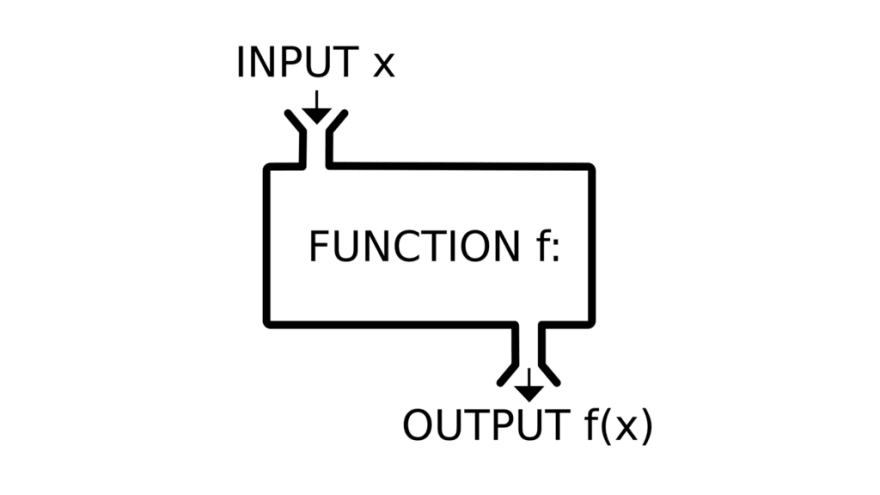

Figure source: https://dev.to/navi/why-functional-programming-matters-2o95

**NOTE:** Functions in R however will only return a single output object. If multiple output objects are desired from the function, one can save this objects in a list and let the list be the output of the function.

Lets write a simple function to greet someone.

```r
Greeting <- function(Name){

  # This functions takes a input parameter (The name) which will be incorporated into the greeting

  # Here we save a string that concatenate the input parameter with the character strings
  string <- paste0("Hello ", Name , ", how are you doing today?")

   # Print the greeting
  print(string)

}

Greeting("Darren")
```

```
## [1] "Hello Darren, how are you doing today?"
```

In this function as we have seen, the greeting is address to yours truly. Lets address it to my colleague Alex.

```r
Greeting("Alex")
```

```
## [1] "Hello Alex, how are you doing today?"
```

As you can see, the functions expects an input which has to be a character string.

We could create functions that does simple calculations such as additions

```r
Addition <- function(x, y){

  #add x to y
  Answer =  x + y

  print(paste0("The answer is: ", Answer))
}

Addition(5, 8)
```

```
## [1] "The answer is: 13"
```

We could for instance also create the function that calculates the area and save it as a variable

```r
Calculate_area_cirle <- function(radius){

  #add x to y
  Area <- pi*radius^2

  return(Area)
}

Area_circle <- Calculate_area_cirle(7)
print(Area_circle)
```

```
## [1] 153.938
```

You can additionally define a default value for each input in the function. When no value is specified for the parameter, the function will take the default value as input as shown in the example.

```r
Calculate_area_cirle <- function(radius=6){

  #add x to y
  Area <- pi*radius^2

  return(Area)
}

Area_circle <- Calculate_area_cirle() # No value given, default value will be used
print(Area_circle)
```

```
## [1] 113.0973
```

```r
Area_circle <- Calculate_area_cirle(10) # Default value will be overwritten by 10
print(Area_circle)
```

```
## [1] 314.1593
```

## 5.1 R exercises: Reinforce your knowlege

1. Create a function that prints out “Welcome to the world of bioinformatics, my name is **Name** and I am **age** years old.”
2. Create a function to calculate the human body mass index (BMI). The formula for BMI is $(\frac{Mass(kg)}{heighe (m^2)})$.
3. Create a function to calculate area and circumference of a circle and return the outputs as variables. Think about how you can do that.
4. Create you own function.

# 6 Tidyverse Environment

The Tidyverse environment is a collection of R-packages that is specifically developed for data analyses, data manipulation and many others. It is particularly well suited for manipulation of data frames. Some examples of such packages includes:

- dplyr: This package makes data manipulation like filtering, summarization or combining data frames easier. Complex data manipulation can be done with a few simple lines of code when compare to base R functions.
- tidyr: It is also a package designed for manipulation that includes functions like pivot_longer(). This function will turn data frames into so called “tidydata” which makes further manipulation or visualization easier.
- ggplot2: A flexible and customizable package designed for visualization. One can plot scatterplots, barplots, lineplots and many more with simple lines of code syntax
- stringr: Consists of functions that makes string manipulation easier.

Furthermore, coding in tidyverse environment is consistent and it includes the usage of the pipe operator (%>%). pipe (%>%) allows for multiple data manipulation or visualization functions to be run consequently one after another.

To sum it up, tidyverse is a powerful package with a variety of functions designed for data frames manipulation, data analysis visualization which makes the code more manageable. In the following sections, we will work specifically in the tidyverse environment with some example data sets

## 6.1 Data manipulation and transformation with dplyr

We will first load the tidyverse package.

```r
library(tidyverse)
```

In the following examples, we will work with the Iris flower data set available from the tidyverse package. This data set includes 50 samples of 3 speices of the *Iris* flowers (*Iris setosa*, *Iris virginica* und *Iris versicolor*). The measured characteristics are the length and width of the sepals and petals of the flowers.

```r
head(iris)
```

```
##   Sepal.Length Sepal.Width Petal.Length Petal.Width Species
## 1          5.1         3.5          1.4         0.2  setosa
## 2          4.9         3.0          1.4         0.2  setosa
## 3          4.7         3.2          1.3         0.2  setosa
## 4          4.6         3.1          1.5         0.2  setosa
## 5          5.0         3.6          1.4         0.2  setosa
## 6          5.4         3.9          1.7         0.4  setosa
```

Wir can summarize the data using the function “summary()”

```r
summary(iris)
```

```
##   Sepal.Length    Sepal.Width     Petal.Length    Petal.Width
##  Min.   :4.300   Min.   :2.000   Min.   :1.000   Min.   :0.100
##  1st Qu.:5.100   1st Qu.:2.800   1st Qu.:1.600   1st Qu.:0.300
##  Median :5.800   Median :3.000   Median :4.350   Median :1.300
##  Mean   :5.843   Mean   :3.057   Mean   :3.758   Mean   :1.199
##  3rd Qu.:6.400   3rd Qu.:3.300   3rd Qu.:5.100   3rd Qu.:1.800
##  Max.   :7.900   Max.   :4.400   Max.   :6.900   Max.   :2.500
##        Species
##  setosa    :50
##  versicolor:50
##  virginica :50
##
##
##
```

dplyr as mentioned, is a package that makes data manipulation and filtering much easier. * summarise() Summarise data the Data. It will however create a new data frame. * filter() Filter the data frame rows conditionally. * select() Filter the column by selecting the column names. * rename() Renaming of the column names * arrange() Sorting of the rows. * mutate() Adding a new column * transmute() Create a new data frame that only consists of the newly created column.

With the function “filter()”, We can filter the thr rows by the values

```r
setosa <- iris %>%
  filter(Species=="setosa") # Filter of rows with the value "Setosa"
print(setosa)
```

We could combine the “filter()” function with another function (in this case “str_detect()” from stringr) to filter rows by character string positions,

```r
 virginica <- iris %>%
  filter(str_detect(Species,"nica")) # Filter of rows by character string position
print(virginica)
```

The “select()” function selects for column by column names.

```r
 Sepal <- iris %>%
  select(Sepal.Length,Sepal.Width) #Select columns of the Sepal.Length and Sepal.Width
print(Sepal)
```

Select() can also be used in a way to select for all columns with the name patterns.

```r
 Sepal <- iris %>%
  select(contains("Sepal")) #Select columns of the Sepal.Length and Sepal.Width
print(Sepal)
```

arrange() sorts the data frame based on the sepal length in ascending or descending order

```r
 iris %>%
  arrange(Sepal.Length) # Sorts data frame based on sepal length in ascending order

iris %>%
  arrange(desc(Sepal.Length)) # Sorts data frame based on sepal length in descending order
```

With rename(), one can rename the column names

```r
iris_new_name <- iris %>% rename(Sepal_Lenth = Sepal.Length)
print(iris_new_name)
```

You probably noticed, that the code often consists of this symbol %>%. This represents the pipe operator in R. It can take the output of one function and transfer it then to the next function as shown below.

```r
# In the following code, we see multiple functions being ran one after another
iris_new <- iris %>%
  select(Sepal.Length,Sepal.Width,Species) %>% # First the columns were selected based on column names
  filter(Species=="setosa") %>% # Second the species column is filtered for rows that contains "setosa"
  arrange(Sepal.Length) # Lastly, the data frame is sorted according to the sepal length in ascending order

print(iris_new)
```

If a new column needs to be added, you can use the mutate(), transmute or summarise() Function. What difference does the three functions has will be shown in the following examples

```r
# Hier we calculated the sepal and petal area and saved them as two new columns
iris_new <- iris %>% mutate(Sepal.Area = Sepal.Length * Sepal.Width,
                Petal.Area = Petal.Length * Petal.Width)
print(head(iris_new))
```

```
##   Sepal.Length Sepal.Width Petal.Length Petal.Width Species Sepal.Area
## 1          5.1         3.5          1.4         0.2  setosa      17.85
## 2          4.9         3.0          1.4         0.2  setosa      14.70
## 3          4.7         3.2          1.3         0.2  setosa      15.04
## 4          4.6         3.1          1.5         0.2  setosa      14.26
## 5          5.0         3.6          1.4         0.2  setosa      18.00
## 6          5.4         3.9          1.7         0.4  setosa      21.06
##   Petal.Area
## 1       0.28
## 2       0.28
## 3       0.26
## 4       0.30
## 5       0.28
## 6       0.68
```

In the above example, the area of the sepal and petal was calculated and saved as new columns in the same data frame. If we use transmute instead to add new columns similarly with the calculated areas of sepals and petals, We will essentially be creating a new data frame of only the calculated sepal and petal areas.

```r
# Hier we calculated the sepal and petal area and saved them as two new columns in a new data frame
iris_new <- iris %>% transmute(Sepal.Area = Sepal.Length * Sepal.Width,
                Petal.Area = Petal.Length * Petal.Width)
print(head(iris_new))
```

```
##   Sepal.Area Petal.Area
## 1      17.85       0.28
## 2      14.70       0.28
## 3      15.04       0.26
## 4      14.26       0.30
## 5      18.00       0.28
## 6      21.06       0.68
```

The function summarise() on the other hand is commonly used to calculate basic statistical values like mean, median or standard deviation which will output a new data frame itself with only the calculations defined within the “summarise()” function. It is often use in conjunction with the function “group_by()” to group samples together for the calculations as shown

```r
iris_summary <- iris %>%
  group_by(Species) %>% # The iris data frame is first grouped by species
  summarise( # With "summarise()", we calculate the mean, standard deviation and median of the Sepal.Length
    Mean_Sepal_Length = mean(Sepal.Length),
    SD_Sepal_Length = sd(Sepal.Length),
    Median_Sepal_Length = median(Sepal.Length)
  )
print(iris_summary)
```

```
## # A tibble: 3 × 4
##   Species    Mean_Sepal_Length SD_Sepal_Length Median_Sepal_Length
##   <fct>                  <dbl>           <dbl>               <dbl>
## 1 setosa                  5.01           0.352                 5
## 2 versicolor              5.94           0.516                 5.9
## 3 virginica               6.59           0.636                 6.5
```

With these three examples, we can see clearly the difference between “mutate()”, “transmute()” and “summarise()”, “mutate()” creates new columns that will be saved in the same data frame while “transmute” will save the newly created columns into new data frame that was based on the input data frame. “summarise()” does a summary calculation of the input dataframe based on the specific defined groups

In summary, dplyr is a useful and powerful tool for data manipulation. There are naturally more functions that weren’t described in this tutorial. You can however look it up in the dplyer handbook on the web https://dplyr.tidyverse.org/reference/index.html.

## 6.2 Tidydata and visualization of data with ggplot2

### 6.2.1 Concept von Tidydata

In tidyverse, you will often hear the term “tidydata”, tidydata is a method of data organization in that every variable have a separate column, every observation have a unique row and the column names are easy to read. The function we will use to convert data to tidy data is “pivot_longer()”

```r
iris_tidy <- iris %>%
  pivot_longer(
    cols = c(Sepal.Length, Sepal.Width, Petal.Length, Petal.Width), # Columns that will be saved in Measurement
    names_to = "Measurement", # Defining the column name of the observations
    values_to = "Value" # Defining the column name of the measurement values
  )
print(iris_tidy)
```

In the example of iris data set, we summarized the data with multiple measurement observations namely the length and width of sepal and petal in the “Measurement” column. The measurement values were however stored in the new column “Value”.

The iris data was a easy example where all columns except for the species were measurement values that were numeric. What if we have a more complex data with different classes of columns like the mpg data.

```r
print(head(mpg))
```

```
## # A tibble: 6 × 11
##   manufacturer model displ  year   cyl trans      drv     cty   hwy fl    class
##   <chr>        <chr> <dbl> <int> <int> <chr>      <chr> <int> <int> <chr> <chr>
## 1 audi         a4      1.8  1999     4 auto(l5)   f        18    29 p     compa…
## 2 audi         a4      1.8  1999     4 manual(m5) f        21    29 p     compa…
## 3 audi         a4      2    2008     4 manual(m6) f        20    31 p     compa…
## 4 audi         a4      2    2008     4 auto(av)   f        21    30 p     compa…
## 5 audi         a4      2.8  1999     6 auto(l5)   f        16    26 p     compa…
## 6 audi         a4      2.8  1999     6 manual(m5) f        18    26 p     compa…
```

We will first select the variables that we are interested in. In the selected variables, **Displacement**, **City** and **Cylinders** are numeric and we want to summarize them into a single variable.

```r
mpg_tidy <- mpg %>%
  # Umbennenung von der Variablen
  rename(
    Manufacturer = manufacturer,
    Model = model,
    Engine_Displacement = displ,
    No_Cylinders = cyl,
    Fuel_type = fl,
    City_mpg = cty,
    Highway_mpg = hwy,
    Drive_typr = drv,
    Class = class
  ) %>%
  select(Manufacturer,Model,Engine_Displacement,No_Cylinders,Fuel_type,City_mpg,Class) %>% #Selekt nur Variablen die wir uns interessieren
  #
 pivot_longer(
   cols = c(Engine_Displacement,City_mpg,No_Cylinders), # Columns that will be saved in the "Measurement_Type" column
   names_to = "Measurement_Type", # Defining the new column name
   values_to = "Value" # Defining the column name of the measurement values of the observation
 )

# View the tidy "mpg" dataset
head(mpg_tidy)
```

```
## # A tibble: 6 × 6
##   Manufacturer Model Fuel_type Class   Measurement_Type    Value
##   <chr>        <chr> <chr>     <chr>   <chr>               <dbl>
## 1 audi         a4    p         compact Engine_Displacement   1.8
## 2 audi         a4    p         compact City_mpg             18
## 3 audi         a4    p         compact No_Cylinders          4
## 4 audi         a4    p         compact Engine_Displacement   1.8
## 5 audi         a4    p         compact City_mpg             21
## 6 audi         a4    p         compact No_Cylinders          4
```

As we seen, tidydata simplify the understanding of the data by converting the data from a wide format to a long format. This reduces mistakes in the data due to inconsisten naming. It is also often important for the visualization of the data which we will see in the next section.

### 6.2.2 Visualisierung mit ggplot2

ggplot2 is a flexible, powerful and customizable package in R for data visualization. ggplot2 is built as a grammar-graphics framework which can create complex and highly customizable plots. The code of ggplot2 can be divided into different fundamental parts namely the Data, aesthetics and geometry. Asthetics represents the variables that will be plotted in the plots. One can also define the size and color of the data points in this part. Geometry represents the type of plots like barplots, boxplots or scatterplots. We will see some examples of how ggplot2 plot codes can be written

```r
# Here we convert the iris data to tidy data
iris_tidy <- iris %>%
  pivot_longer(
    cols = c(Sepal.Length, Sepal.Width, Petal.Length, Petal.Width),
    names_to = "Measurement",
    values_to = "Value"
  )
head(iris_tidy)
```

```
## # A tibble: 6 × 3
##   Species Measurement  Value
##   <fct>   <chr>        <dbl>
## 1 setosa  Sepal.Length   5.1
## 2 setosa  Sepal.Width    3.5
## 3 setosa  Petal.Length   1.4
## 4 setosa  Petal.Width    0.2
## 5 setosa  Sepal.Length   4.9
## 6 setosa  Sepal.Width    3
```

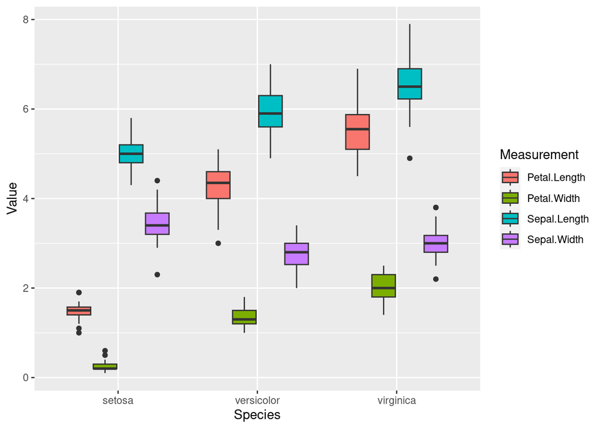

```r
ggplot(iris_tidy, # Data is defined
       aes(x = Species, y = Value, fill = Measurement)) + # Variables of the data is defined
  geom_boxplot() # Type of plots that will be plotted
```

We see in the above example that boxplots of both the length and width (cm) of the sepal and petal were plotted. The X, Y variables and the legend names depends on the column names of the given data frame. The variable names in the plot itself can also be specified. We can additionally separate the plots by their respective measurements in so called facets.

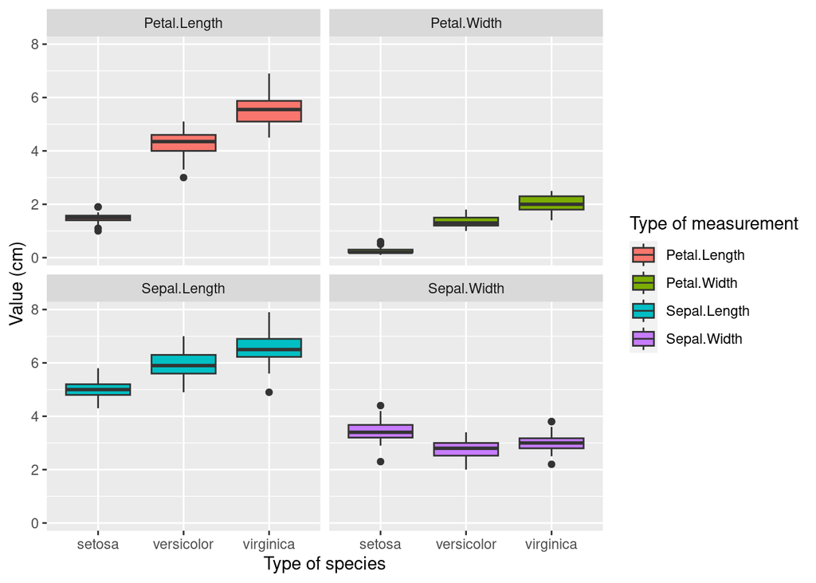

```r
ggplot(iris_tidy, aes(x = Species, y = Value, fill = Measurement)) +
  geom_boxplot() +
  labs(x = "Type of species", # Name of X axis
       y = "Value (cm)", # Name of Y axis
       fill = "Type of measurement") +  # Name of the legend
  facet_wrap(~Measurement) # separation of the plot by Measurement column values
```

We can even change the plots to how its depicted. In the following example, we changed the x axis variables to the measurement type instead of the species and vice-versa. We also added extra line of code in order to specify that the x axis variable labels has to be rotated to 90 degrees.

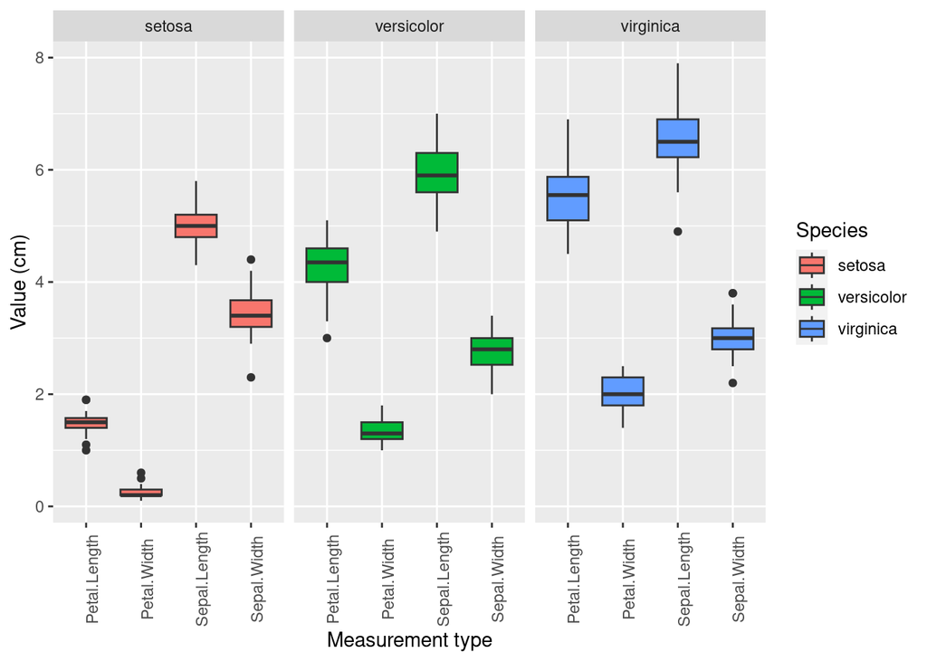

```r
ggplot(iris_tidy, aes(x = Measurement, y = Value, fill = Species)) +
  geom_boxplot() +
  labs(x = "Measurement type", # Name of X axis
       y = "Value (cm)", # Name of Y axis
       fill = "Species") +  # Name of the legend
  facet_wrap(~Species) + # separation of the plot by Measurement column values
  theme(axis.text.x = element_text(angle = 90))
```

We could also represent the data in a bar plot. However, remember that we have multiple measurement values from deviation species of the iris flower. Hence we have to first summarise them. Lets summarise them by their mean and standard devation.

```r
# Summarizing the tidy data of iris by their mean and standard deviation
summary_iris <- iris_tidy %>%
  group_by(Species, Measurement) %>%
  summarise(mean_value = mean(Value),
            SD_value = sd(Value))
```

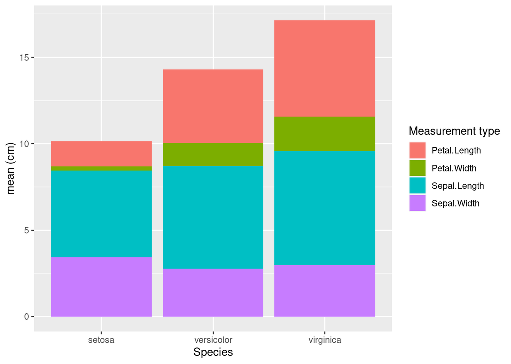

```r
ggplot(summary_iris, aes(x = Species, y = mean_value, fill = Measurement)) +
  geom_bar(stat = "identity") + labs(x = "Species",
                                     y ="mean (cm)",
                                     fill = "Measurement type")
```

In the above example, we created a vertical stacked bar plots of every species of iris flower. Of course, we can further customize the plot. Lets turn the bar plot horizontal and change the background to white instead of gray,

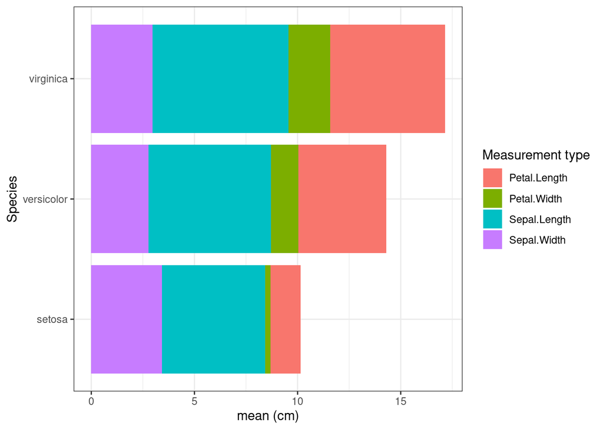

```r
ggplot(summary_iris, aes(x = Species, y = mean_value, fill = Measurement)) +
  geom_bar(stat = "identity") + labs(x = "Species",
                                     y ="mean (cm)",
                                     fill = "Measurement type") +
                                     coord_flip() + # filp the plot to horizontal
                                     theme_bw() # change the background to white
```

Maybe a stacked bar plots is not clear to everyone. Lets plot each measurement type as a single bar plot. Additionally lets include the error bars using the standard deviation we calculated earlier.

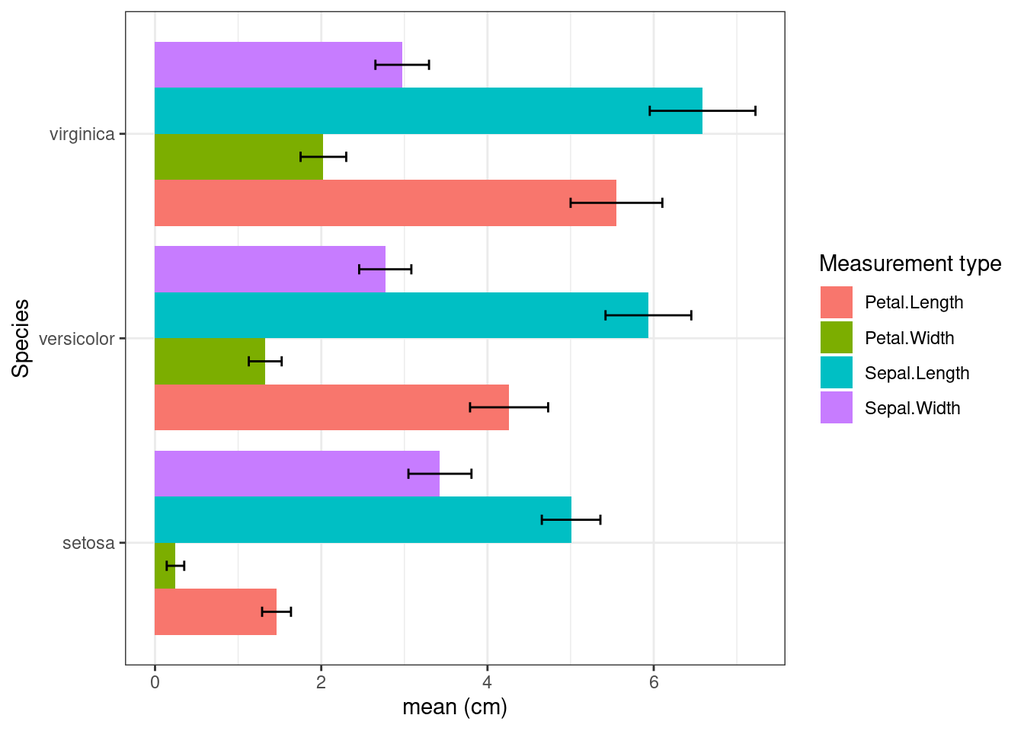

```r
ggplot(summary_iris, aes(x = Species, y = mean_value, fill = Measurement)) +
  geom_bar(stat = "identity", position = "dodge") + # position = "dodge" signals to ggplot2 that the bar plots should not be stacked
  labs(x = "Species",
       y ="mean (cm)",
       fill = "Measurement type") +
  geom_errorbar(aes(ymin=mean_value-SD_value,  # adding error bars using the standara deviation we calculated
                    ymax=mean_value+SD_value),
                    width=0.2,
                    position=position_dodge(0.9)) +
  coord_flip() +
  theme_bw()
```

Maybe we want to observe if there is any linear relationship between the measurements. We could model this using a scatter plot. With scatter plots, it will be easier if we worked with the original iris data set. Lets plot the relationship between the sepal length and petal length

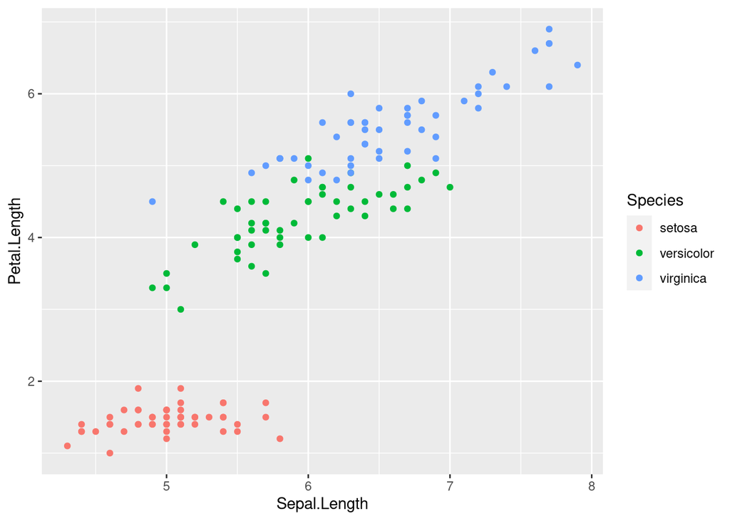

```r
ggplot(data = iris) +
  aes(x = Sepal.Length, y = Petal.Length) +
  geom_point(aes(color = Species))
```

We could even fit a linear model in the plot itself

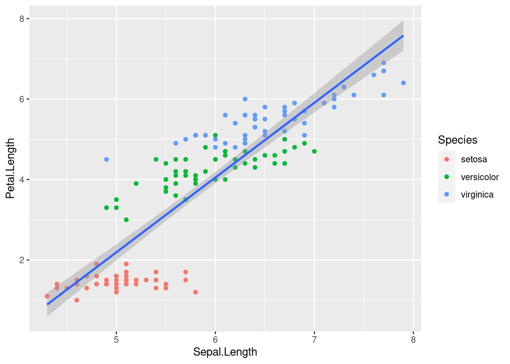

```r
ggplot(data = iris) +
  aes(x = Sepal.Length, y = Petal.Length) +
  geom_point(aes(color = Species)) +
  geom_smooth(method = lm)
```

## 6.3 R exercises: Reinforce your knowlege

1. First load the diamonds data set into your console. The diamonds data set is one of many example data sets of tidyverse that anyone can use to perform data analyses or visualization. The data set describes the attributes of diamonds, namely;
- Price: Cost in USD
- carat: Represents the weight of the diamonds
- cut: The quality of the diamond cut
- color: The color of the diamond which range from “J”(worst) to “D”(best)
- clarity: Categorical measurement of how clear the diamond is ((I1 (worst), SI2, SI1, VS2, VS1, VVS2, VVS1, IF (best))).
- depth: Total depth percentage. Calculated by the $(\frac{depth(z)}{mean(length(x),width(y))}*100)$
- table: Percentage of width of the top of the diamond that is relative to its widest point
- x, y and z: Length, width and depth respectively More information can be found in https://www.kaggle.com/datasets/shivam2503/diamonds
2. First rename the x, y and z variable to their respective measurements using the dplyr package.
3. Plot a scatter to model the linear relationship between the carat and the price. In addition label each data point in accordance to their clarity.
- You could also log transform the data to reduce heteroscedasticity
4. Select the columns of price, carat, cut, color, clarity and depth. Convert this subset data frame into a tidydata table.
5. Plot box plots with the x axis being the cut, the y axis being the carat. group them by their color. You will need to first filter the observations to obtain only the “carat” observation. You may also need to transform the data to reduce heteroscedasticity
6. Plot a histogram of the of the frequency of the price grouped by their cut. You will need to first filter the observations to obtain only the “price” observation.
7. From the original data set of diamonds;
- select the clarity, x, y ,z and convert it to tidy data.
- Group them by the clarity and calculate the mean, standard deviation, median, maximum and minimum values of the each of the measurement types namely the x, y and z.
- Plot a bar plot with the y axis being the mean of the measurement type and the x axis being the clarity. Include error bars using the standard deviation and separate them into different facets by their measurements.
8. What can you conclude from the plots that you have created?

# 7 Other miscellaneous stuffs in R to know

## 7.1 Installing packages and loading them

It’s highly unlikely that you will work only with base R, hence its important to know how to install packages when need be. Packages can easily be installed with the code shown below. **NOTE:** Depending on your operating system of your computer, you might be required to install dependencies in order to install the packages that you desire.

```r
install.packages("tidyverse")
```

Loading packages can be done with the code shown below.

```r
library(tidyverse)
```

Or you can load them directly from the RStudio interface as shown.

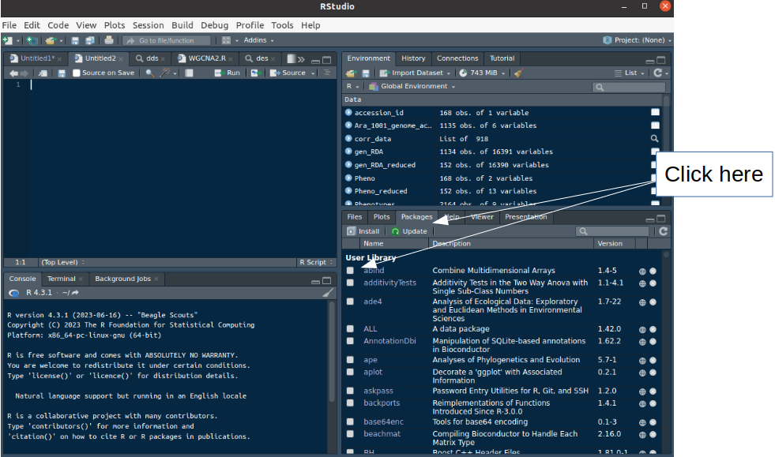

## 7.2 Importing external Data sets into R

```r
multiqc_star <- read.delim("/media/rna/BAIJI/Darren_Doktorand/Genomanalyse_und_Phylogenie_2023-2024/Tag_1_Einfuehrung_in_R/multiqc_star.txt")
```

You could also do it through the Rstudio interface as shown. Select “Import Dataset”, thereafter select the data type you want to import.

[figure not shown]

Look for the data you want to import in your computer and click on it.

[figure not shown]

Finally, select the options on how the data is supposed to be imported.

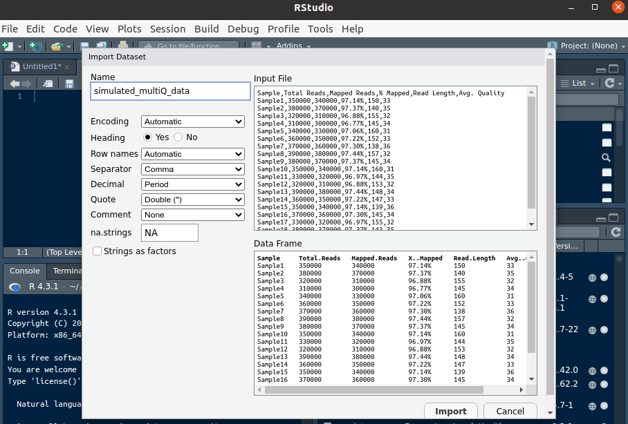

# 8 Bonus: Alignment statistics of sugar beets

## 8.1 Context and motivation

Plants are constantly bombarded with a variety of stress. Due to their sessile nature, they have to employ strategies to cope with the ever changing environment. These strategies includes genome mutations, alteration in gene expression patterns or epigenetic modifications. Sugar beets are no different in this aspect. In this particular study, the authors looked into the link between epigenetic modification and gene expression of sugar beets grown in colder environments as compared to control. To do that, they performed mRNA sequencing as well as Whole genome bisulfite sequencing to elucidate the underlying mechanisms controlling cold-adaptation in sugar beets (Gutschker *et al*. 2022).

## 8.2 Study desgin

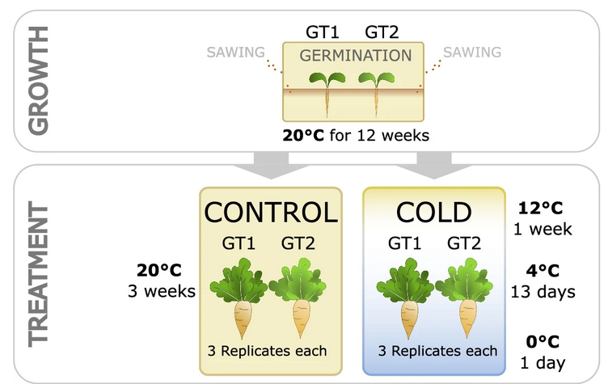

Study design of the cold tolerance in sugar beet. Two genotypes were subjected to cold treatment with respective controls (Figure source: Gutschker *et al*. 2022)

## 8.3 The data set

You will find in your project folder a text file called **multiqc_star.txt**. It will contains multiple information about the alignment statistics of the the mRNA sequencing fragments of the sugar beet paper. These statistics include the total number of reads, total aligned reads, average read length and many others.

## 8.4 Your task

1. Load the text file into your R console.
2. Find of the **mean** of the total number of input reads, total reads that were **uniquely** mapped, total reads that were **multimapped**, total unmapped reads (reads that too short or others) and the mean mapped read length **regardless of their sample groupings**
3. Find out if there is a linear relationship between the total number of splice junctions and uniquely mapped reads.
4. Think of a best way to represent how many reads were **uniquely** mapped in comparison with **multimapped** and **unmapped** reads for each of the groups.
5. Continue exploring the data yourself!

# 9 What now?

Practice, practice and more practice

For a more comprehensive tutorial you can refer to this book: https://r4ds.had.co.nz/index.html

# 10 References and sources

- Gutschker, S.; Corral, J.M.; Schmiedl, A.; Ludewig, F.; Koch, W.; Fiedler-Wiechers, K.; Czarnecki, O.; Harms, K.; Keller, I.; Rodrigues, C.M.; et al. Multi-omics data integration reveals link between epigenetic modifications and gene expression in sugar beet (Beta vulgaris subsp. vulgaris) in response to cold. BMC Genom. 2022, 23, 144.
- https://cran.r-project.org/doc/contrib/Paradis-rdebuts_en.pdf
- https://www.kaggle.com/datasets/shivam2503/diamonds
- https://www.tidyverse.org/packages/
- Mastermodul_2023_R_basics_Tag1-1.pdf by David Rüscher
- https://r4ds.had.co.nz/index.html